# Análisis de las defunciones maternas en PBA durante 2009-2021.

Fabio Gallardo

## Introducción

Los datos que se presentan corresponden a las defunciones maternas en provincia de Buenos Aires registradas durante el periodo del 2009 a 2021. Los mismo se encuentran en el catálogo de datos abiertos de la Dirección Provincial de Estadística y Salud Digital (https://catalogo.datos.gba.gob.ar/dataset/defunciones-maternas).

Las muertes de mujeres provocadas por problemas ocurridos durante el proceso reproductivo tienen consecuencias profundamente negativas para las familias en las cuales estos hechos ocurren y para la comunidad en general. La mortalidad materna y la mortalidad infantil son indicadores de la situación socio-económica de la población del país, de la organización del sistema sanitario, de la cobertura y de la calidad de los servicios.

## Exploración de los datos

```r
defunciones_maternas_2009_2021 <- read_excel("datos/defunciones-maternas-2009-2021.xlsx")
```

A continuación tenemos una presentación preliminar de la composición de la base de datos:

```r
defunciones_maternas_2009_2021 |>
  head() %>%
  gt()
```

| anio | region_sanitaria | municipio_id | municipio_nombre | CIE10_codigo | CIE10_descripcion | clasificacion | cantidad |
| --- | --- | --- | --- | --- | --- | --- | --- |
| 2009 | Ignorado | Ignorado | Ignorado | O99 | OTRAS AFECCIONES OBSTETRICAS NO CLASIFICADAS EN OTRA PARTE (O95 - O99) | INDIRECTA | 1 |
| 2009 | VI | 06028 | Almirante Brown | O85 | COMPLICACIONES PRINCIPALMENTE RELACIONADAS CON EL PUERPERIO (O85 - O92) | DIRECTA | 1 |
| 2009 | VI | 06028 | Almirante Brown | O15 | EDEMA, PROTEINURIA Y TRASTORNOS HIPERTENSIVOS EN EL EMBARAZO, EL PARTO Y EL PUERPERIO (O10 - O16) | DIRECTA | 1 |
| 2009 | VI | 06028 | Almirante Brown | O99 | OTRAS AFECCIONES OBSTETRICAS NO CLASIFICADAS EN OTRA PARTE (O95 - O99) | INDIRECTA | 2 |
| 2009 | IX | 06049 | Azul | O99 | OTRAS AFECCIONES OBSTETRICAS NO CLASIFICADAS EN OTRA PARTE (O95 - O99) | INDIRECTA | 1 |
| 2009 | IV | 06070 | Baradero | O99 | OTRAS AFECCIONES OBSTETRICAS NO CLASIFICADAS EN OTRA PARTE (O95 - O99) | INDIRECTA | 1 |

Respecto a la estructuración de la base de datos está compuesta por 8 variables y 1018 observaciones.

```r
str(defunciones_maternas_2009_2021)
```

```
## tibble [1,018 × 8] (S3: tbl_df/tbl/data.frame)
##  $ anio             : num [1:1018] 2009 2009 2009 2009 2009 ...
##  $ region_sanitaria : chr [1:1018] "Ignorado" "VI" "VI" "VI" ...
##  $ municipio_id     : chr [1:1018] "Ignorado" "06028" "06028" "06028" ...
##  $ municipio_nombre : chr [1:1018] "Ignorado" "Almirante Brown" "Almirante Brown" "Almirante Brown" ...
##  $ CIE10_codigo     : chr [1:1018] "O99" "O85" "O15" "O99" ...
##  $ CIE10_descripcion: chr [1:1018] "OTRAS AFECCIONES OBSTETRICAS NO CLASIFICADAS EN OTRA PARTE (O95 - O99)" "COMPLICACIONES PRINCIPALMENTE RELACIONADAS CON EL PUERPERIO (O85 - O92)" "EDEMA, PROTEINURIA Y TRASTORNOS HIPERTENSIVOS EN EL EMBARAZO, EL PARTO Y EL PUERPERIO (O10 - O16)" "OTRAS AFECCION…
##  $ clasificacion    : chr [1:1018] "INDIRECTA" "DIRECTA" "DIRECTA" "INDIRECTA" ...
##  $ cantidad         : num [1:1018] 1 1 1 2 1 1 1 1 1 1 ...
```

Las variables “region_sanitaria, municipio_id, municipio_nombre, CIE10_codigo, CIE10_descripcion, y clasificación” son categóricas y las variables “año y cantidad” numéricas.

Respecto de las variables cuantitativas presentan estas propiedades:

```r
defunciones_maternas_2009_2021|>
  select(anio, cantidad)|>
  summary()
```

```
##       anio         cantidad
##  Min.   :2009   Min.   : 1.000
##  1st Qu.:2011   1st Qu.: 1.000
##  Median :2014   Median : 1.000
##  Mean   :2015   Mean   : 1.192
##  3rd Qu.:2018   3rd Qu.: 1.000
##  Max.   :2021   Max.   :10.000
```

La frecuencia de muertes maternas durante los años 2009 a 2021 es la siguiente:

```r
defunciones_maternas_2009_2021 %>%
  select(anio, cantidad) %>%
  group_by(anio) %>%
  summarise(cantidad_muertes_informadas = sum(cantidad)) %>%
  gt()
```

| anio | cantidad_muertes_informadas |
| --- | --- |
| 2009 | 112 |
| 2010 | 128 |
| 2011 | 92 |
| 2012 | 86 |
| 2013 | 86 |
| 2014 | 100 |
| 2015 | 111 |
| 2016 | 92 |
| 2017 | 72 |
| 2018 | 89 |
| 2019 | 61 |
| 2020 | 65 |
| 2021 | 119 |

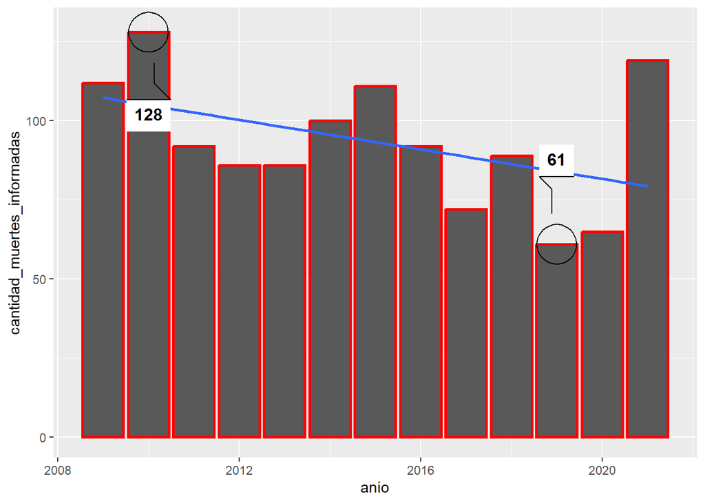

```r
defunciones_maternas_2009_2021 %>%
  select(anio, cantidad) %>%
  group_by(anio) %>%
  summarise(cantidad_muertes_informadas = sum(cantidad)) %>%
ggplot(aes(anio, cantidad_muertes_informadas)) +
  geom_col(color="Red", size=1)+
  geom_smooth(method = "lm", alpha=0)+
  ggforce::geom_mark_circle(aes(filter = cantidad_muertes_informadas == max(cantidad_muertes_informadas),
                                label = cantidad_muertes_informadas))+
  ggforce::geom_mark_circle(aes(filter = cantidad_muertes_informadas == min(cantidad_muertes_informadas),
                                label = cantidad_muertes_informadas))
```

Desagregando los resultados, la tabla siguiente presenta las frecuencias de muertes maternas dentro de la Región Sanitaria VI en el periodo 2009 al 2021:

```r
defunciones_maternas_2009_2021 %>%
  filter(`region_sanitaria `== "VI") %>%
  select(anio, cantidad) %>%
  group_by(anio) %>%
  summarise(cantidad_muertes_informadas = sum(cantidad)) %>%
  gt()
```

| anio | cantidad_muertes_informadas |
| --- | --- |
| 2009 | 31 |
| 2010 | 32 |
| 2011 | 21 |
| 2012 | 28 |
| 2013 | 16 |
| 2014 | 22 |
| 2015 | 23 |
| 2016 | 30 |
| 2017 | 15 |
| 2018 | 22 |
| 2019 | 14 |
| 2020 | 13 |
| 2021 | 25 |

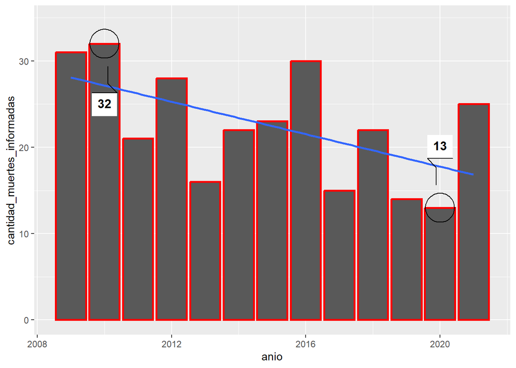

```r
defunciones_maternas_2009_2021 %>%
  filter(`region_sanitaria `== "VI") %>%
  select(anio, cantidad) %>%
  group_by(anio) %>%
  summarise(cantidad_muertes_informadas = sum(cantidad)) %>%
  ggplot(aes(anio, cantidad_muertes_informadas)) +
  geom_col(color="Red", size=1)+
  geom_smooth(method = "lm", alpha=0)+
  ggforce::geom_mark_circle(aes(filter = cantidad_muertes_informadas == max(cantidad_muertes_informadas),
                                label = cantidad_muertes_informadas))+
  ggforce::geom_mark_circle(aes(filter = cantidad_muertes_informadas == min(cantidad_muertes_informadas),
                                label = cantidad_muertes_informadas))
```

Enfocándonos en las muertes maternas donde las causas obstétricas son directas, es decir aquellas que resultan de complicaciones obstétricas del embarazo (embarazo, parto y puerperio), de intervenciones, de omisiones, de tratamiento incorrecto, o de una cadena de acontecimientos originada en cualquiera de las circunstancias, el mayor registro en PBA es de “embarazo terminado en aborto”. Tal como lo muestra la siguiente tabla de frecuencias de registros por diagnóstico CIE 10:

```r
defunciones_maternas_2009_2021 %>%
  filter(clasificacion == "DIRECTA") %>%
  select(CIE10_descripcion, cantidad) %>%
  group_by(CIE10_descripcion) %>%
  summarise(cantidad_muertes_informadas = sum(cantidad)) %>%
  arrange(desc(cantidad_muertes_informadas)) %>%
  gt()
```

| CIE10_descripcion | cantidad_muertes_informadas |
| --- | --- |
| EMBARAZO TERMINADO EN ABORTO (O00 - O08) | 223 |
| COMPLICACIONES PRINCIPALMENTE RELACIONADAS CON EL PUERPERIO (O85 - O92) | 160 |
| COMPLICACIONES DEL TRABAJO DE PARTO Y DEL PARTO (O60 - O75) | 155 |
| EDEMA, PROTEINURIA Y TRASTORNOS HIPERTENSIVOS EN EL EMBARAZO, EL PARTO Y EL PUERPERIO (O10 - O16) | 155 |
| OTRAS AFECCIONES OBSTETRICAS NO CLASIFICADAS EN OTRA PARTE (O95 - O99) | 95 |
| ATENCION MATERNA RELACIONADA CON EL FETO Y LA CAVIDAD AMNIOTICA Y CON POSIBLES PROBLEMAS DEL PARTO (O30-O48) | 32 |
| OTROS TRASTORNOS MATERNOS RELACIONADOS PRINCIPALMENTE CON EL EMBARAZO (O20 - O29) | 29 |

Lo mismo sucede para la región Sanitaria VI, el mayor registro es de “embarazo terminado en aborto”.

```r
defunciones_maternas_2009_2021 %>%
  filter(`region_sanitaria `== "VI", clasificacion == "DIRECTA") %>%
  select(CIE10_descripcion, cantidad) %>%
  group_by(CIE10_descripcion) %>%
  summarise(cantidad_muertes_informadas = sum(cantidad)) %>%
  arrange(desc(cantidad_muertes_informadas)) %>%
  gt()
```

| CIE10_descripcion | cantidad_muertes_informadas |
| --- | --- |
| EMBARAZO TERMINADO EN ABORTO (O00 - O08) | 56 |
| COMPLICACIONES DEL TRABAJO DE PARTO Y DEL PARTO (O60 - O75) | 42 |
| COMPLICACIONES PRINCIPALMENTE RELACIONADAS CON EL PUERPERIO (O85 - O92) | 40 |
| EDEMA, PROTEINURIA Y TRASTORNOS HIPERTENSIVOS EN EL EMBARAZO, EL PARTO Y EL PUERPERIO (O10 - O16) | 40 |
| OTRAS AFECCIONES OBSTETRICAS NO CLASIFICADAS EN OTRA PARTE (O95 - O99) | 28 |
| OTROS TRASTORNOS MATERNOS RELACIONADOS PRINCIPALMENTE CON EL EMBARAZO (O20 - O29) | 6 |
| ATENCION MATERNA RELACIONADA CON EL FETO Y LA CAVIDAD AMNIOTICA Y CON POSIBLES PROBLEMAS DEL PARTO (O30-O48) | 4 |

El siguiente gráfico muestra que a pesar que el “embarazo terminado en aborto” es la causa mas frecuente de muerte materna directa en PBA, se encuentra en descenso:

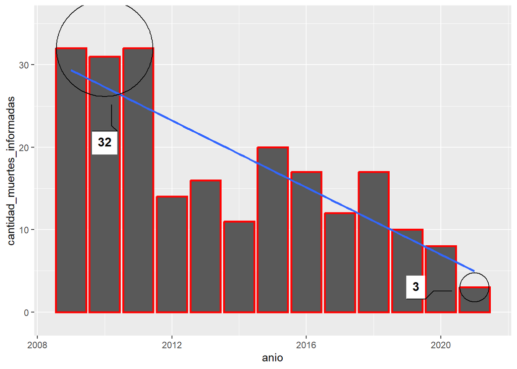

```r
defunciones_maternas_2009_2021 %>%
  filter(CIE10_descripcion == "EMBARAZO TERMINADO EN ABORTO (O00 - O08)") %>%
  group_by(anio) %>%
  summarise(cantidad_muertes_informadas = sum(cantidad)) %>%
  ggplot(aes(anio, cantidad_muertes_informadas)) +
  geom_col(color="Red", size=1)+
  geom_smooth(method = "lm", alpha=0)+
  ggforce::geom_mark_circle(aes(filter = cantidad_muertes_informadas == max(cantidad_muertes_informadas),
                                label = cantidad_muertes_informadas))+
  ggforce::geom_mark_circle(aes(filter = cantidad_muertes_informadas == min(cantidad_muertes_informadas),
                                label = cantidad_muertes_informadas))
```

Respecto a las muertes maternas donde las causas obstétricas son indirectas (resultan de enfermedad existente desde antes del embarazo o de una enfermedad que evoluciona durante el mismo, no debidas a causas obstétricas directas, pero sí agravadas por los efectos fisiológicos del embarazo) se observa una elevación abrupta durante el 2021 en PBA:

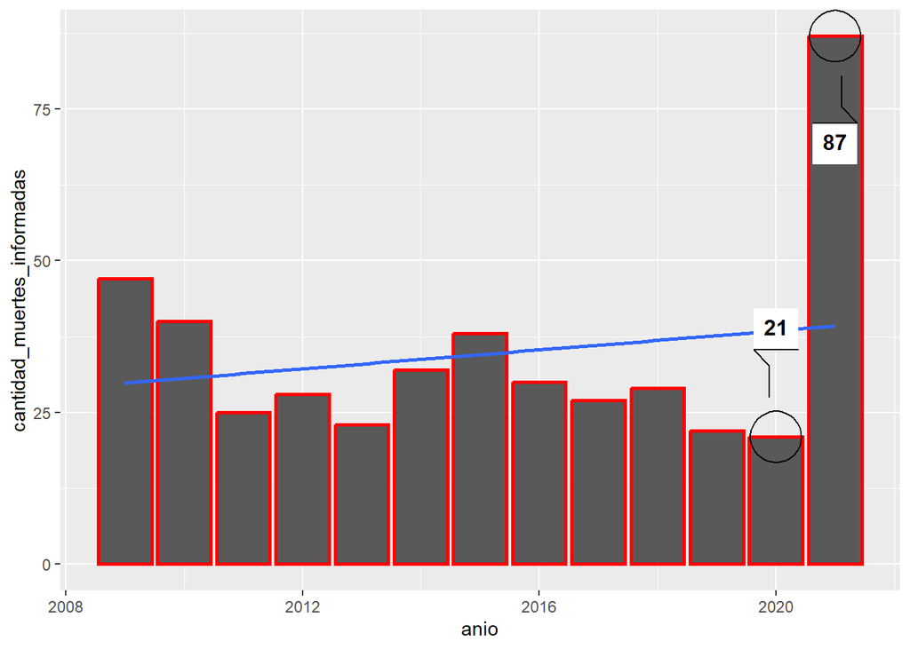

```r
defunciones_maternas_2009_2021 %>%
  filter(CIE10_descripcion == "OTRAS AFECCIONES OBSTETRICAS NO CLASIFICADAS EN OTRA PARTE (O95 - O99)") %>%
  group_by(anio) %>%
  summarise(cantidad_muertes_informadas = sum(cantidad)) %>%
  ggplot(aes(anio, cantidad_muertes_informadas)) +
  geom_col(color="Red", size=1)+
  geom_smooth(method = "lm", alpha=0)+
  ggforce::geom_mark_circle(aes(filter = cantidad_muertes_informadas == max(cantidad_muertes_informadas),
                                label = cantidad_muertes_informadas))+
  ggforce::geom_mark_circle(aes(filter = cantidad_muertes_informadas == min(cantidad_muertes_informadas),
                                label = cantidad_muertes_informadas))
```

## Hipótesis

¿Existen diferencias entre las tasas de mortalidad materna entre las diferentes Regiones Sanitarias?

Se comparó la tasa de 4 regiones sanitarias: V, VI, VII y XII. Son las regiones que se encuentran en las zonas de mayor concentración poblacional en la PBA.

```r
tabla_regio_an <-defunciones_maternas_2009_2021 %>%
  group_by(anio,`region_sanitaria `) %>%
  summarise(cantidad_muertes_informadas = sum(cantidad)) %>%
  pivot_wider(names_from = `region_sanitaria `,
              values_from = cantidad_muertes_informadas,
              values_fill = 0) %>%
  select(c(V, VI, VII, XII)) %>%
  print()
```

```
## # A tibble: 13 × 5
## # Groups:   anio [13]
##     anio     V    VI   VII   XII
##    <dbl> <dbl> <dbl> <dbl> <dbl>
##  1  2009    27    31    14    13
##  2  2010    19    32    33    18
##  3  2011    23    21    13    15
##  4  2012    19    28    10     9
##  5  2013    19    16    20     7
##  6  2014    22    22    21    10
##  7  2015    21    23    22    15
##  8  2016    16    30    15     8
##  9  2017    15    15    14     8
## 10  2018    25    22     7    11
## 11  2019    14    14    11     7
## 12  2020    13    13    13     6
## 13  2021    24    25    19    16
```

Para el calculo de las tasas por año de estas cuatro regiones fue necesario tener la cantidad de nacidos vivos de cada región.

Nuevamente se recurrió al catálogo de datos abiertos de la Dirección Provincial de Estadística y Salud Digital.

```r
nacidos_vivos_regiones_PBA <- read_excel("datos/nacidos_vivos_regiones_PBA.xlsx")
gt(nacidos_vivos_regiones_PBA)
```

| anio | V | VI | VII | XII |
| --- | --- | --- | --- | --- |
| 2005 | 54706 | 67630 | 38088 | 24840 |
| 2006 | 55774 | 66110 | 38221 | 25170 |
| 2007 | 56193 | 67081 | 38612 | 26101 |
| 2008 | 59432 | 73163 | 40813 | 28341 |
| 2009 | 59683 | 72541 | 40519 | 28227 |
| 2010 | 61576 | 74738 | 41851 | 28994 |
| 2011 | 62490 | 75980 | 42398 | 29423 |
| 2012 | 60768 | 72834 | 40454 | 28663 |
| 2013 | 62430 | 74601 | 42030 | 28890 |
| 2014 | 62890 | 75793 | 42582 | 29246 |
| 2015 | 60811 | 73046 | 42215 | 28593 |
| 2016 | 57228 | 68740 | 39828 | 26678 |
| 2017 | 55096 | 67301 | 37787 | 25918 |
| 2018 | 51735 | 63777 | 36485 | 24625 |
| 2019 | 48236 | 57094 | 32385 | 22513 |
| 2020 | 39065 | 47842 | 27710 | 18778 |
| 2021 | 39970 | 46769 | 26082 | 18407 |

Se busco conjugar ambas bases para poder calcular las tasas.

```r
nacidos_vivos_regiones_PBA <- read_excel("datos/nacidos_vivos_regiones_PBA.xlsx") |>
  pivot_longer(cols = -anio, names_to = "region_sanitaria", values_to = "nacidos_vivos") %>%
  print()
```

```
## # A tibble: 68 × 3
##     anio region_sanitaria nacidos_vivos
##    <dbl> <chr>                    <dbl>
##  1  2005 V                        54706
##  2  2005 VI                       67630
##  3  2005 VII                      38088
##  4  2005 XII                      24840
##  5  2006 V                        55774
##  6  2006 VI                       66110
##  7  2006 VII                      38221
##  8  2006 XII                      25170
##  9  2007 V                        56193
## 10  2007 VI                       67081
## # ℹ 58 more rows
```

```r
defunciones_maternas_2009_2021 %>%
  group_by(anio, region_sanitaria = `region_sanitaria ` ) %>%
  summarise(cantidad_muertes_informadas = sum(cantidad)) |>
  left_join(nacidos_vivos_regiones_PBA) |>
  mutate(tasa = round(
    (cantidad_muertes_informadas/nacidos_vivos)*100000, 2)) %>%
  select(anio, region_sanitaria, tasa) %>%
  filter(region_sanitaria %in% c("V", "VI", "VII", "XII")) %>%
  pivot_wider(names_from = region_sanitaria,
              values_from = tasa)
```

```
## # A tibble: 13 × 5
## # Groups:   anio [13]
##     anio     V    VI   VII   XII
##    <dbl> <dbl> <dbl> <dbl> <dbl>
##  1  2009  45.2  42.7  34.6  46.1
##  2  2010  30.9  42.8  78.8  62.1
##  3  2011  36.8  27.6  30.7  51.0
##  4  2012  31.3  38.4  24.7  31.4
##  5  2013  30.4  21.4  47.6  24.2
##  6  2014  35.0  29.0  49.3  34.2
##  7  2015  34.5  31.5  52.1  52.5
##  8  2016  28.0  43.6  37.7  30.0
##  9  2017  27.2  22.3  37.0  30.9
## 10  2018  48.3  34.5  19.2  44.7
## 11  2019  29.0  24.5  34.0  31.1
## 12  2020  33.3  27.2  46.9  32.0
## 13  2021  60.0  53.4  72.8  86.9
```

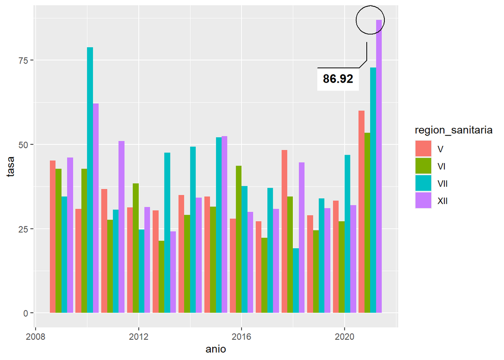

```r
defunciones_maternas_2009_2021 %>%
  group_by(anio, region_sanitaria = `region_sanitaria ` ) %>%
  summarise(cantidad_muertes_informadas = sum(cantidad)) |>
  left_join(nacidos_vivos_regiones_PBA) |>
  mutate(tasa = round(
    (cantidad_muertes_informadas/nacidos_vivos)*100000, 2)) %>%
  select(anio, region_sanitaria, tasa) %>%
  filter(region_sanitaria %in% c("V", "VI", "VII", "XII")) %>%
  ggplot(aes(anio, tasa))+
  geom_col(aes(fill=region_sanitaria), position = "dodge")+
  ggforce::geom_mark_circle(aes(filter = tasa == max(tasa),
                                label = tasa))
```

¿Las causas directas e indirectas tienen la misma tendencia de aparición durante el periodo 2009 a 2021?

```r
tabla_anio_cla <- defunciones_maternas_2009_2021 %>%
  group_by(anio, clasificacion) %>%
  summarise(cantidad_muertes_informadas = sum(cantidad)) %>%
  pivot_wider(names_from = clasificacion,
              values_from = cantidad_muertes_informadas,
              values_fill = 0) %>%
  print()
```

```
## # A tibble: 13 × 3
## # Groups:   anio [13]
##     anio DIRECTA INDIRECTA
##    <dbl>   <dbl>     <dbl>
##  1  2009      70        42
##  2  2010      97        31
##  3  2011      81        11
##  4  2012      65        21
##  5  2013      72        14
##  6  2014      77        23
##  7  2015      80        31
##  8  2016      66        26
##  9  2017      49        23
## 10  2018      66        23
## 11  2019      44        17
## 12  2020      46        19
## 13  2021      36        83
```

La tabla muestra la cantidad de muertes por año según causas directas o indirectas.

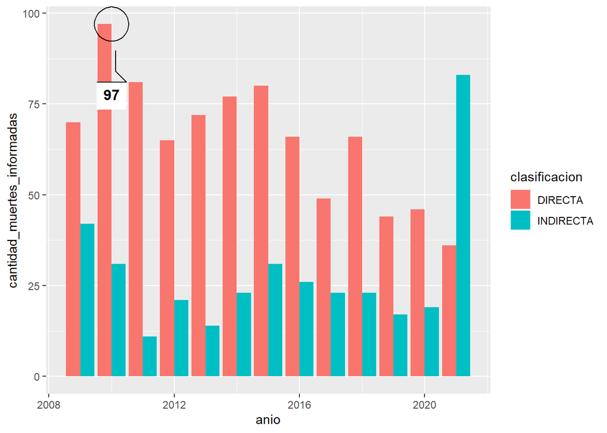

```r
defunciones_maternas_2009_2021 %>%
  group_by(anio, clasificacion) %>%
  summarise(cantidad_muertes_informadas = sum(cantidad)) %>%
  ggplot(aes(anio, cantidad_muertes_informadas))+
  geom_col(aes(fill=clasificacion), position = "dodge")+
  ggforce::geom_mark_circle(aes(filter = cantidad_muertes_informadas == max(cantidad_muertes_informadas),
                                label = cantidad_muertes_informadas))
```

El gráfico muestra que de las muertes maternas directas tienen una tendencia en descenso para el periodo analizado. En cambio, las muertes maternas indirectas se encontraban en una meseta, pero del 2020 al 2021 registran un aumento elevado. Muchos artículos informan sobre esto, debido al impacto que tuvo el COVID en las embarazadas.

¿Las causas de muerte materna según clasificación CIE 10 tuvieron el mismo porcentaje de frecuencia durante el periodo 2009 a 2021?

A continuación, se presenta la tabla de frecuencia observada, ya que los porcentajes se sacaron con Excel.

```r
defunciones_maternas_2009_2021 %>%
  group_by(anio, CIE10_descripcion) %>%
  summarise(cantidad_muertes_informadas = sum(cantidad)) %>%
  pivot_wider(names_from = anio,
              values_from = cantidad_muertes_informadas,
              values_fill = 0)
```

```
## # A tibble: 8 × 14
##   CIE10_descripcion      `2009` `2010` `2011` `2012` `2013` `2014` `2015` `2016`
##   <chr>                   <dbl>  <dbl>  <dbl>  <dbl>  <dbl>  <dbl>  <dbl>  <dbl>
## 1 ATENCION MATERNA RELA…      1      3      2      2      4      2      3      3
## 2 COMPLICACIONES DEL TR…      8     23     12     10     13     13     21     14
## 3 COMPLICACIONES PRINCI…     11     15      7     14     15     18     11     19
## 4 EDEMA, PROTEINURIA Y …     10     14     11     15     12     18     12      6
## 5 EMBARAZO TERMINADO EN…     32     31     32     14     16     11     20     17
## 6 ENFERMEDAD POR VIRUS …      1      1      0      2      1      4      1      0
## 7 OTRAS AFECCIONES OBST…     47     40     25     28     23     32     38     30
## 8 OTROS TRASTORNOS MATE…      2      1      3      1      2      2      5      3
## # ℹ 5 more variables: `2017` <dbl>, `2018` <dbl>, `2019` <dbl>, `2020` <dbl>,
## #   `2021` <dbl>
```